# Lab_1 Plastic Waste

```r
library(tidyverse)
```

```r
plastic_waste <- read_csv("C:/Users/prana/Desktop/IS-680-R/plastic-waste.csv")
```

```r
spec(plastic_waste)
```

```r
plastic_waste
```

| code | entity | continent | year | gdp_per_cap | plastic_waste_per_cap | mismanaged_plastic_waste_per_cap | mismanaged_plastic_waste | coastal_pop | total_pop |
| --- | --- | --- | --- | --- | --- | --- | --- | --- | --- |
| AFG | Afghanistan | Asia | 2010 | 1614.2550 | NA | NA | NA | NA | 31411743 |
| ALB | Albania | Europe | 2010 | 9927.1818 | 0.069 | 0.032 | 29705 | 2530533 | 3204284 |
| DZA | Algeria | Africa | 2010 | 12870.6027 | 0.144 | 0.086 | 520555 | 16556580 | 35468208 |
| ASM | American Samoa | Oceania | 2010 | NA | NA | NA | NA | NA | 68420 |
| AND | Andorra | Europe | 2010 | NA | NA | NA | NA | NA | 84864 |
| AGO | Angola | Africa | 2010 | 5897.6828 | 0.062 | 0.045 | 62528 | 3790041 | 19081912 |
| AIA | Anguilla | North America | 2010 | NA | 0.252 | 0.010 | 52 | 14561 | 15358 |
| ATG | Antigua and Barbuda | North America | 2010 | 19212.7201 | 0.660 | 0.051 | 1253 | 66843 | 88710 |
| ARG | Argentina | South America | 2010 | 18712.0631 | 0.183 | 0.026 | 157777 | 16449245 | 40412376 |
| ARM | Armenia | Europe | 2010 | 6702.8480 | NA | NA | NA | NA | 3092072 |

[output cut: 230 more lines]

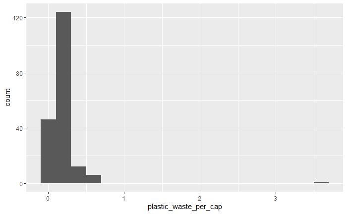

```r
ggplot(data = plastic_waste, aes(x = plastic_waste_per_cap)) +
  geom_histogram(binwidth = 0.2)
```

```r
plastic_waste %>%
  filter(plastic_waste_per_cap > 3.5)
```

| code | entity | continent | year | gdp_per_cap | plastic_waste_per_cap | mismanaged_plastic_waste_per_cap | mismanaged_plastic_waste | coastal_pop | total_pop |
| --- | --- | --- | --- | --- | --- | --- | --- | --- | --- |
| TTO | Trinidad and Tobago | North America | 2010 | 31260.91 | 3.6 | 0.19 | 94066 | 1358433 | 1341465 |

**Exercise_1:**

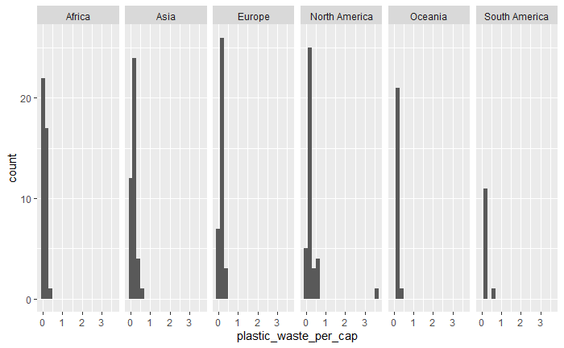

```r
ggplot(data = plastic_waste, aes(x = plastic_waste_per_cap)) +
  facet_grid(.~continent) +
  geom_histogram(binwidth = 0.2)
```

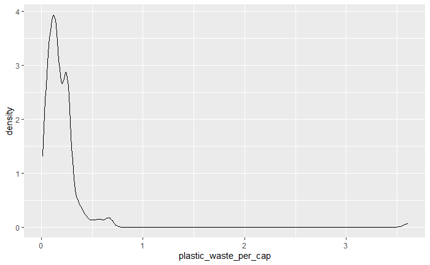

```r
ggplot(data = plastic_waste, aes(x = plastic_waste_per_cap)) +
  geom_density()
```

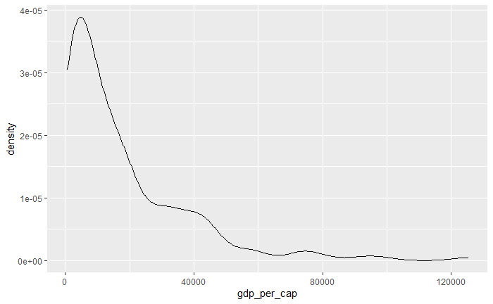

```r
ggplot(data = plastic_waste, aes(x = gdp_per_cap)) +
  geom_density()
```

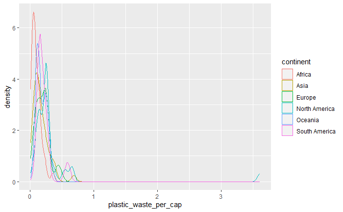

```r
ggplot(data = plastic_waste,
       mapping = aes(x = plastic_waste_per_cap,
                     color = continent)) +
  geom_density()
```

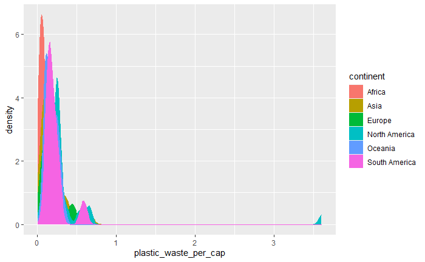

```r
ggplot(data = plastic_waste,
       mapping = aes(x = plastic_waste_per_cap,
                     color = continent,
                     fill = continent)) +
  geom_density()
```

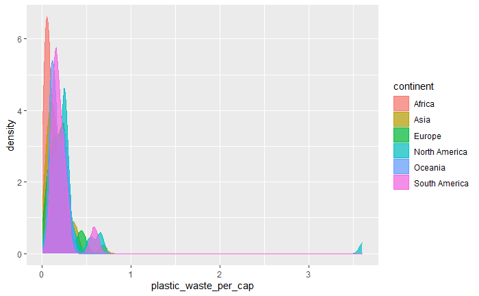

```r
ggplot(data = plastic_waste,
       mapping = aes(x = plastic_waste_per_cap,
                     color = continent,
                     fill = continent)) +
  geom_density(alpha = 0.7)
```

**Exercise_2:**

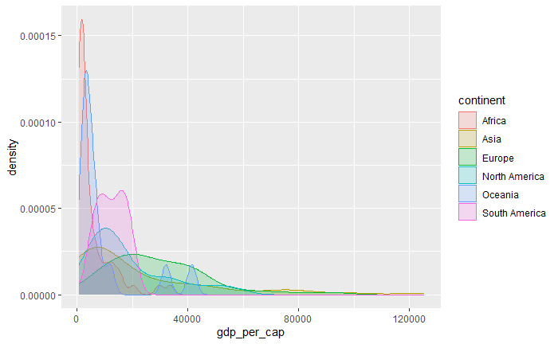

```r
ggplot(data = plastic_waste,
       mapping = aes(x = gdp_per_cap,
                     color = continent,
                     fill = continent)) +
  geom_density(alpha = 0.2)
```

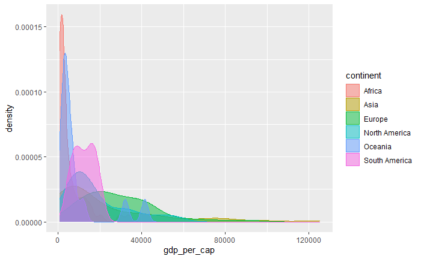

```r
ggplot(data = plastic_waste,
       mapping = aes(x = gdp_per_cap,
                     color = continent,
                     fill = continent)) +
  geom_density(alpha = 0.5)
```

**Exercise_3:**

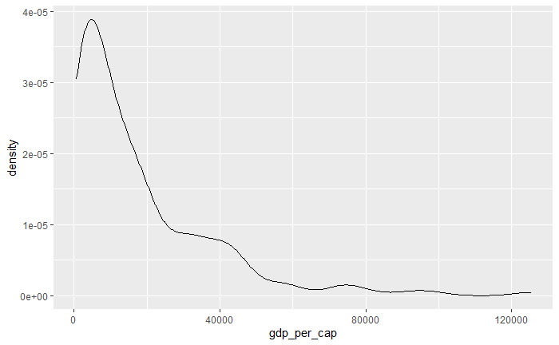

```r
ggplot(data = plastic_waste,
       mapping = aes(x = gdp_per_cap,
                     )) +
  geom_density(alpha = 0.5)
```

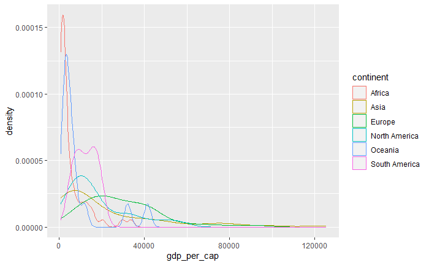

```r
ggplot(data = plastic_waste,
       mapping = aes(x = gdp_per_cap,
                     color = continent,
                    )) +
  geom_density(alpha = 0.5)
```

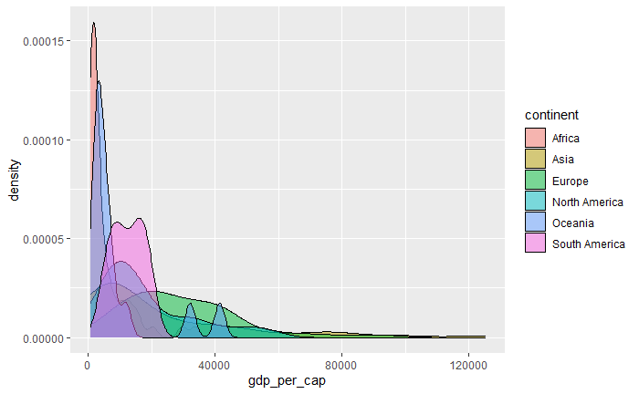

```r
ggplot(data = plastic_waste,
       mapping = aes(x = gdp_per_cap,
                     fill = continent)) +
  geom_density(alpha = 0.5)
```

Where as, in the second plot in which we have used color inside the ggplot we get the borders of the gdp_per_cap of every continents.

In addition, the third plot where we used the fill in the ggplot it will fill the place below the borders with the colors.

In sum we use color and fill for coloring the continents and alpha to set the opacity of the plot.

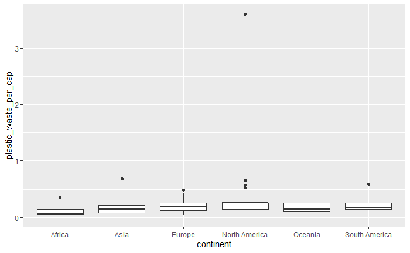

```r
ggplot(data = plastic_waste,
       mapping = aes(x = continent,
                     y = plastic_waste_per_cap)) +
  geom_boxplot()
```

**Exercise_4:**

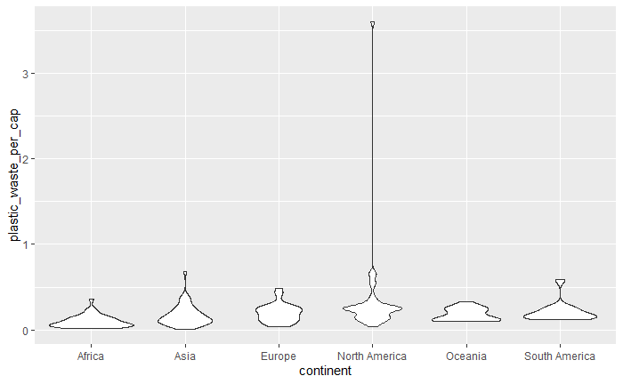

```r
ggplot(data = plastic_waste,
       mapping = aes(x = continent,
                     y = plastic_waste_per_cap)) +
  geom_violin()
```

As you can see the violin plot, it nicely reveals the structure in the data whereas box plot does not do that.

Basically violin plots can plot the numerical data while the box plot is used to plot statistics such as the mean, median and iqr ranges.

**Exercise_5:**

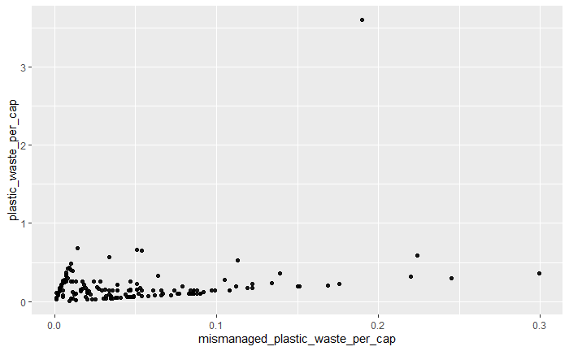

```r
ggplot(plastic_waste, aes(mismanaged_plastic_waste_per_cap, plastic_waste_per_cap)) +
  geom_point(alpha = 0.9)
```

**Exercise_6:**

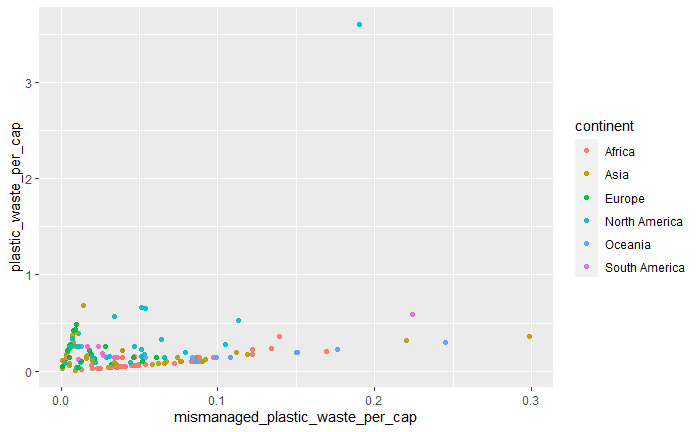

```r
ggplot(plastic_waste, aes(mismanaged_plastic_waste_per_cap, plastic_waste_per_cap,
                          color = continent,
                          fill = continent)) +
  geom_point(alpha = 0.9)
```

Looking at the plot we can say that which color describes the respective continent perfectly.

**Exercise_7:**

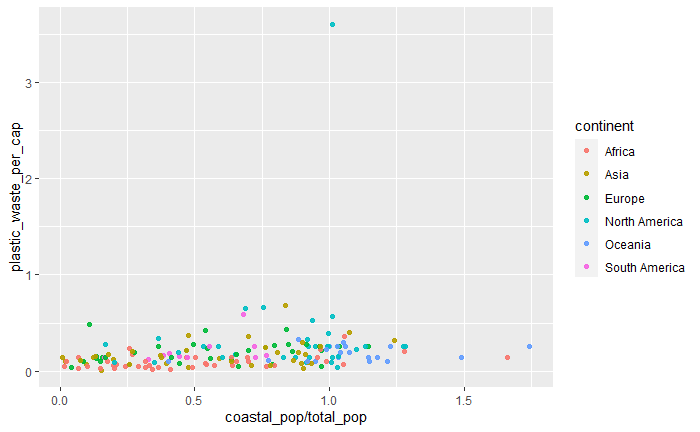

```r
ggplot(plastic_waste, aes(coastal_pop/total_pop, plastic_waste_per_cap,
                          color = continent,
                          fill = continent)) +
  geom_point(alpha = 0.9)
```

```r
  labs(x="Plastic waste per captia", y="Coastal population proportion(coastal/total population)")
```

```
$x
[1] "Plastic waste per captia"

$y
[1] "Coastal population proportion(coastal/total population)"

attr(,"class")
[1] "labels"
```